# Principal Component Analysis (PCA) Notes

Principal component analysis (PCA) is used when we would like to identify which variables in our dataset are actually useful in predicting an outcome. PCA is made easier with the *caret* package in **R**.

- In some cases, we may have several correlated predictors. Perhaps a weighted average of these predictors will be more useful to our model than having all of the predictors in there separately.
- If we have predictors $X_1, X_2, \dots, X_p$, PCA can produce a new set of uncorrelated predictors $Z_1, Z_2, \dots, Z_k$ where each $Z_i$ is a linear combination of original predictors and $k < p$.
- If we have $n$ rows of data, we can think of this as $n$ points in $p$-dimensional space, which we would like to project into $k$ dimensional space. The goal is to do this in a way that minimizes the sum of squared errors from the original points to their projections.
- The PCA algorithm accomplishes this by maximizing the covariance matrix of the projected values, in both trace and determinant.
- The first principal component $p_1$ will be a weighted average of the predictors $X_1, X_2, \dots, X_p$ with the highest possible variance. The second component $p_2$ will have the second highest variance and be uncorrelated with $p_1$, and so on.

## Potential Issues

- It is a good idea to standardize all of the variables before beginning PCA, since the method is not scale-invariant. Remember that when we eventually standardize the variables in the test set, we will need to use the mean and standard deviation from the training set!
- Since we are working with linear combinations of variables, the results of this model may be difficult to interpret or explain. This method will work best when we are interested in predicting future outcomes or missing values, but don’t need to explain the relationships between the outcome and specific predictors.

## Application in **R**

First we should load in the *mtcars* dataset to use as an example. This data set has 10 predictor variables for the outcome *mpg* (Miles per gallon).

```r
data(mtcars)
```

We will load the *caret* library, and split the data into training and testing sets. About $\frac{3}{4}$ of the data will be used for training.

```r
#library(knitr)
library(caret)

inTrain <- createDataPartition(y = mtcars$mpg, p = 0.75, list=FALSE)
training <- mtcars[inTrain,]
testing <- mtcars[-inTrain,]
```

Since the PCA method isn’t scale invariant, we will need to standardize the variables. We can do this pretty easily using the *preProcess* function. If we set the method to “pca”, the program will automatically center and scale the variables.

```r
preProc <- preProcess(training[-1], method="pca", pcaComp=2)
```

If we want to set some threshold - say, 80% of the variance explained by the model, we could set ‘thres=0.8’ in the *preProcess* function. To view the principal components, use the ‘rotation’ attribute.

```r
preProc$rotation
```

```
##          PC1      PC2
## cyl  -0.4071  0.04136
## disp -0.4004 -0.04694
## hp   -0.3485  0.26555
## drat  0.3296  0.25857
## wt   -0.3667 -0.16194
## qsec  0.2080 -0.45694
## vs    0.3458 -0.20271
## am    0.2353  0.44458
## gear  0.2035  0.47282
## carb -0.2233  0.40173
```

We can now use this *preProcess* object to train the data and fit a model. Recall that the R-Squared statistic is the explained variation over total variation, which means the percentage of variation that is explained by our model.

```r
mpgPC <- predict(preProc, training[-1])
modelFit <- train(training$mpg~., method="glm", data=mpgPC)
modelFit
```

[output not shown]

In this case, when we use 2 principal components the R-Squared value is 0.8219.

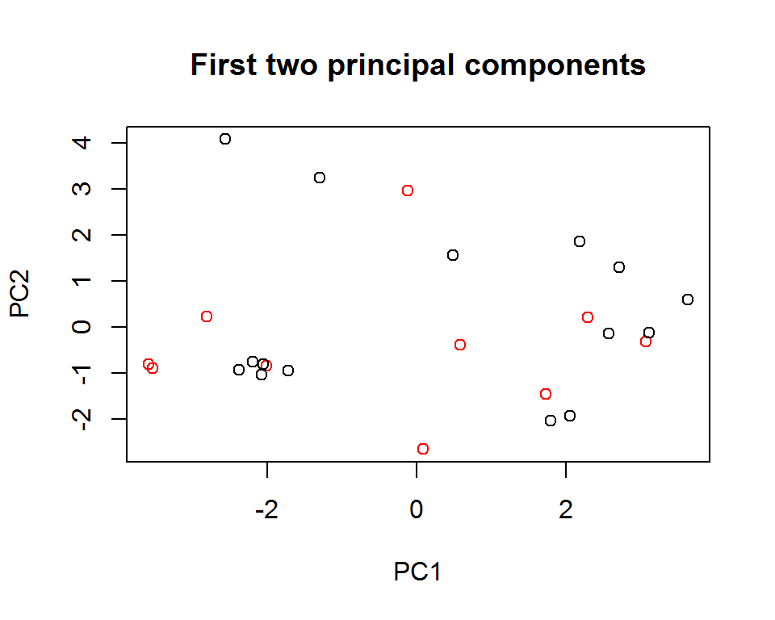

```r
mpgGroup <- cut(mtcars$mpg, c(0,median(mtcars$mpg), max(mtcars$mpg)), labels=c(1,2))
with(mpgPC, plot(PC1, PC2, col=mpgGroup, main='First two principal components'))
```

## References

Leek, Jeff. *Practical Machine Learning* on Coursera. Johns Hopkins Bloomberg School of Public Health. online: https://www.coursera.org/course/predmachlearn. Session: December 1 - 28, 2014.